# Modèles VAR

Henri BERTHET

28/06/2020

```r
library("dse")
library("urca")
library("tsDyn")
library("stringr")
library("mnormt")
```

## Prologue

Nous connaissons les séries chronologiques univariées qui met en jeu un processus x(t). Sous R nous pouvons simuler de tels processus par Arima.sim(), ou bien ajuster un modèle Arma sur une série statistique donnée. L’ajustement soulèvera les problématiques de stationnarité, saisonnalité, order du Arma..etc. Une fois obtenu le bon modèle la prédiction future sera possible. Le but des lignes qui suivent est de généraliser au cas où X(t) est un vecteur multivarié $X(t)=(x_{1}(t),x_{2}(t)…..x_{k}(t)) $. Nous resterons dans le cadre des processus dit "Var(p), c’est à dire du type
$$X_{t}=B_{0}+\sum_{i=1}^{p} B_{i} X_{t-i}+\varepsilon_{t}$$
Les $B_{i}$ étant des matrices k.p (ordre p et dimension k).

Nous proposons dans une première partie une simulation “maison” proche de la définition matricielle, pour nous aider à paramétrer deux fonctions de R, “simulate” et VAR.sim . Ensuite (partie 2) nous aborderons l’estimation par un modèle à l’aide de la fonction VAR(), mais du fait de la présence de plusieurs variables simultanées le problème de la stationnarité sera un peu plus complexe que dans le cas univarié. En plus les différentes variables pouvant interagir les unes par rapport aux autres nous étudierons les concepts de causalité et de cointégration. Pour terminer (partie 3) nous essayerons notre modèle sur un cas concret d’évolution boursière.

Petite remarque: afin d’éviter des “bug” de la fonction “Knit” il est préférable d’utiliser le package “remotes::install_github(‘yihui/knitr’)”

# PREMIERE PARTIE

## Processus Var(p)

On rappelle qu’un processus vectoriel est un VAR(p) s’il est défini par:
$$X_{t}=B_{0}+\sum_{i=1}^{p} B_{i} X_{t-i}+\varepsilon_{t}$$
où $X_{t}$ est un vecteur $(x_{1 t},x_{2 t},...,...,x_{k t})^{'}$ . $\varepsilon_{t}$ est un bruit blanc vectoriel, c’est à dire:
$$E(\varepsilon_{t})=0)$$
et
$$E(\varepsilon_{t},\varepsilon^{'}_{t})=\Sigma_{\epsilon}$$
, où $\Sigma_{\epsilon}$ est la matrice de variances-covariances indépendante de t. Si la matrice $\Sigma_{\epsilon}$ est diagonale, les $\varepsilon{i}_{t}$ sont indépendants.

On peut trouver un définition voisine:
$$AX_{t}=B_{0}+\sum_{i=1}^{p} B_{i} X_{t-i}+\varepsilon_{t}$$
Si A est inversible, on retrouve la première version en multipliant les deux membres de l’égalité par $A^{-1}$ Mais le produit $A^{-1}\varepsilon_{t}$ introduit de nouvelles corrélations dans le bruit blanc.

Il est bon de noter que pour un VAR(1) $t\in[0;+\infty[$ , $X_{0}$ est la condition initiale, et $X_{1}$ est connu par le premier “choc” $\epsilon_{1}$. Nos simulations prendrons en général par défaut $X_{0}=0$

## Une fonction pédagogique

Nous créons une fonction pour générer des processus VAR(p), non pas pour rivaliser avec les fonctions intégrées de R (VAR.sim ou simulate) mais pour mettre en évidence les calculs matriciels nécessaire à la génération. Nous la nommerons var(), elle prendra en paramètres n le nombre d’observations du processus, la matrice A si nécessaire, B, p l’ordre du var sera limité à p=1 et le mode “const” ou “none” suivant qu’il y ait $B_{0}$ ou non. Cette fonction permet de générer des VAR(1) et des bruits blancs gaussiens non corrélés défaut, ou corrélés de matrice de corrélation Sigma.

```r
var=function(n,A=diag(nrow(B)) , B,Sigma=diag(nrow(B)),lag=1,mod=c("const","none","trend")){

  Ai=solve(A)
  C=ncol(B)
  N=nrow(B)
  vdat=matrix(0,N,n)
  start=1+lag

  v=rmnorm(n=n,mean=rep(0,N),varcov=Sigma) ; v=t(v)  # génération du bruit
  if(mod=="none") {
    vdat[,1:lag]=Ai%*%v[,1:lag] # initialisation
    for(i in start:n) {vdat[,i]=Ai%*%(B%*%vdat[,i-lag] +v[,i])}
    return(t(vdat)) } else
      if(mod=="const") {
        vdat[,1:lag]=Ai%*%(v[,1:lag] + B[,1])    # initialisation
        for(i in start:n) {vdat[,i]=Ai%*%(B[,2:C]%*%vdat[,i-lag] +v[,i]+B[,1])}
        return(t(vdat)) } else
          if(mod=="trend") {
            vdat[,1:lag]=Ai%*%(v[,1:lag] + B[,1]+B[,2])    # initialisation
            for(i in start:n) {vdat[,i]=Ai%*%(B[,3:C]%*%vdat[,i-lag] +v[,i]+B[,1]+i*B[,2])}
            return(t(vdat)) }
}
```

A titre d’exemple prenons le Var(1) suivant:
$$\left(\begin{array}{l}x_{t} \\y_{t}\end{array}\right)=\left(\begin{array}{ll}
0.7 & 0.2 \\0.2 & 0.7\end{array}\right)\left(\begin{array}{l}x_{t-1} \\y_{t-1}
\end{array}\right)+\left(\begin{array}{l}
\epsilon_{1_{t}} \\\epsilon_{2_{t}}\end{array}\right)$$

sur 100 réalisations, les $\epsilon_{i}$ des bruits blancs normaux centrés réduits indépendants.

```r
set.seed(123456)
B1<-matrix(c(0.7, 0.2, 0.2, 0.7), 2)
vdat1=var(100,B=B1,lag=1,mod="none")
head(vdat1)
```

```
##           [,1]        [,2]
## [1,] 0.8337332 -0.27604777
## [2,] 0.1734018  0.06100062
## [3,] 2.3858371  0.91184093
## [4,] 3.1648697  3.61810148
## [5,] 4.1072608  2.73947940
## [6,] 2.4268487  1.62513784
```

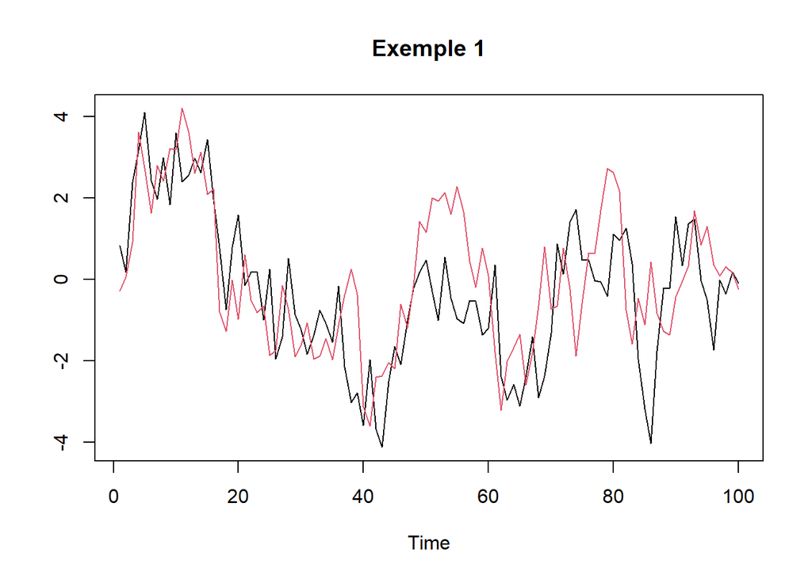

```r
ts.plot(vdat1,type="l",col=c(1,2),main="Exemple 1")
```

Si on veut rajouter une constante, $\left(\begin{array}{ll}0.5\\0.8\end{array}\right)$

```r
set.seed(123456)
B2<-matrix(c(0.5,0.7, 0.2, 0.8,0.2, 0.7),nrow= 2,byrow=T) #constante=c(0.5,0.8)
vdat2=var(100,B=B2,lag=1,mod="const")
head(vdat2)
```

```
##          [,1]      [,2]
## [1,] 1.333733 0.5239522
## [2,] 1.183402 1.5210006
## [3,] 3.884837 2.9358409
## [4,] 5.118970 6.1347015
## [5,] 6.478451 5.6919194
## [6,] 5.177170 4.9660838
```

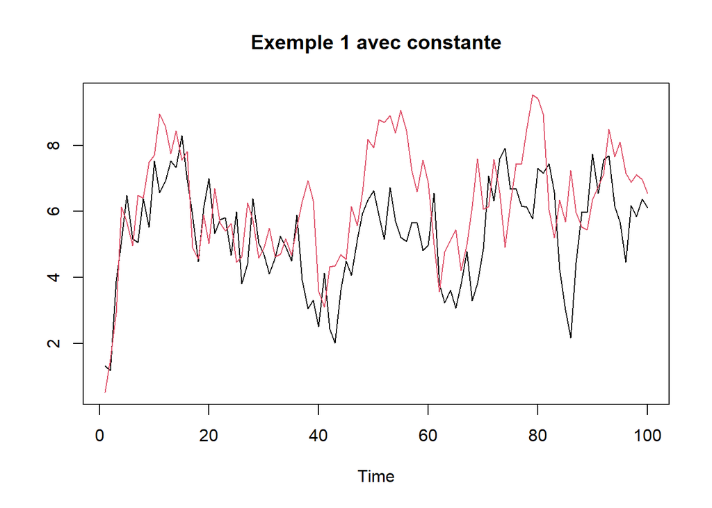

```r
ts.plot(vdat2,type="l",col=c(1,2),main="Exemple 1 avec constante")
```

Remarquons au passage qu’avoir ajouté une constante (0.5;0.8) dans le processus bivarié ne cause pas une translation de 0.5 ou 0.8 sur chaque variable (sauf pour la première valeur).

Enfin on peut introduire une corrélation entre les composantes du bruit blanc.

```r
Cor=matrix(c(1,0.3,0.3,1),2,2) # matrice Sigma
set.seed(123456)
B3<-matrix(c(0.7, 0.2,0.2, 0.7),nrow= 2,byrow=T)
vdat3=var(100,B=B3,lag=1,Sigma=Cor,mod="none")
head(vdat3)
```

```
##           [,1]        [,2]
## [1,] 0.8337332 -0.01321284
## [2,] 0.2259688  0.13445478
## [3,] 2.4373249  1.61101306
## [4,] 3.3407455  4.39627032
## [5,] 4.3860077  3.68947180
## [6,] 2.8119700  2.09835239
```

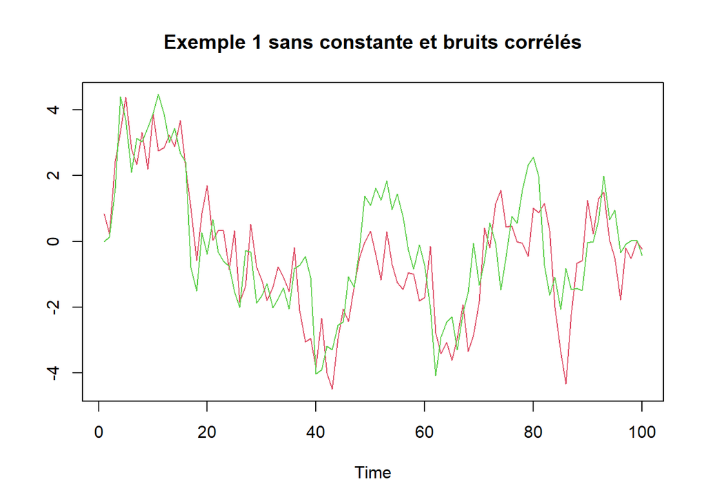

```r
ts.plot(vdat3,type="l",col=c(2,3),main="Exemple 1 sans constante et bruits corrélés")
```

```r
Cor=matrix(c(1,0.3,0.3,1),2,2) # matrice Sigma
set.seed(123456)
B4<-matrix(c(0.5,0.7, 0.2, 0.8,0.2, 0.7),nrow= 2,byrow=T)
vdat4=var(100,B=B2,lag=1,Sigma=Cor,mod="const")
head(vdat4)
```

```
##          [,1]      [,2]
## [1,] 1.333733 0.7867872
## [2,] 1.235969 1.5944548
## [3,] 3.936325 3.6350131
## [4,] 5.294846 6.9128703
## [5,] 6.757198 6.6419118
## [6,] 5.562291 5.4392984
```

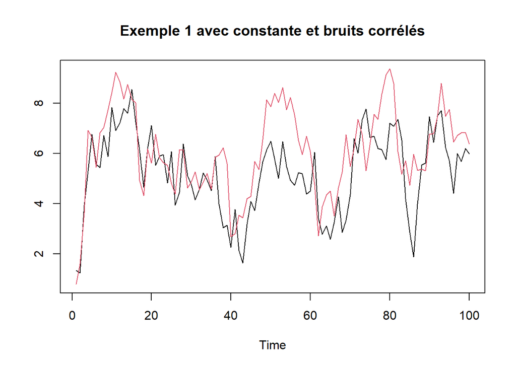

```r
ts.plot(vdat4,type="l",col=c(1,2),main="Exemple 1 avec constante et bruits corrélés")
```

## Fonction “simulate” de R

Cette fonction simule un VAR(p) dont les coefficients sont préalablement définis par VARMA(), tout ceci dans la librairie “dse”.
Pour saisir correctement les coefficients il faut écrire le processus de la façon suivante:
$$Id.X_{t}-\sum_{i=1}^{p} B_{i} X_{t-i}=B_{0}+\varepsilon_{t}$$
et saisir les coefficients de chaque matrice (sans oublier Id !!!) qui occupent les positions L1C1, L2C1, L1C2, L2C2…dans une array de 2 sous matrices 2*2…!! . On peut imposer une matrice B correspondant à un polynôme MA. S’il n’y a pas de composante MA autre que $\varepsilon_{t}$ B est l’identité. Le vecteur constante correspond au paramètre TREND lorsqu’il est utilisé.

Nous allons retrouver les deux processus générés par notre fonction (à condition d’utiliser la même séquence de bruits blancs)

```r
Apoly= array(c(1,-0.7,0,-0.2,0,-0.2,1,-0.7),c(2,2,2))
B = diag(2)
set.seed( 123456)
var1=ARMA(A=Apoly,B=B)
n=100
w=rmnorm(n,mean=c(0,0),varcov=diag(2)) # simulation du bruit
varsim1= simulate(var1,sampleT = 100, noise = w ) #

vardat1=matrix(varsim1$output,nrow = 100,ncol=2)
head(vardat1)
```

```
##           [,1]        [,2]
## [1,] 0.8337332 -0.27604777
## [2,] 0.1734018  0.06100062
## [3,] 2.3858371  0.91184093
## [4,] 3.1648697  3.61810148
## [5,] 4.1072608  2.73947940
## [6,] 2.4268487  1.62513784
```

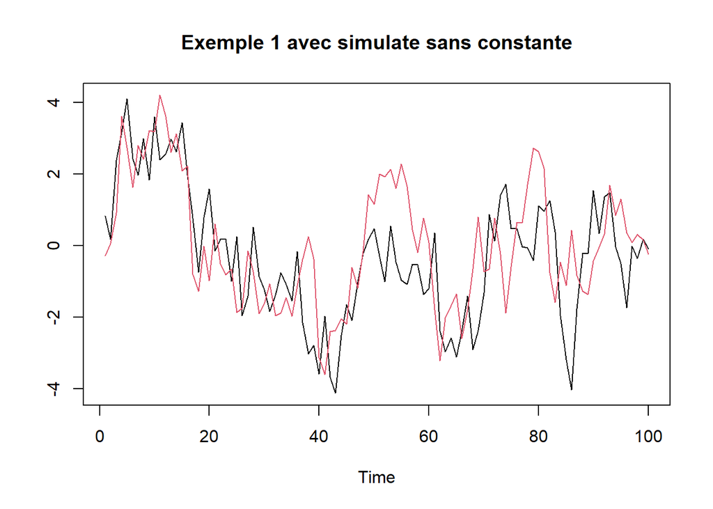

```r
colnames(vardat1)=c( "y1", "y2")
ts.plot(vardat1, type="l", col=c(1,2),main="Exemple 1 avec simulate sans constante")
```

```r
# avec constante
TRD=c(0.5,0.8)
var11=ARMA(A=Apoly,B = B,TREND=TRD)
set.seed( 123456)
varsim11= simulate(var11,sampleT = n,noise = w )
vardat11=matrix(varsim11$output,nrow = 100,ncol=2)
head(vardat11)
```

```
##          [,1]      [,2]
## [1,] 1.333733 0.5239522
## [2,] 1.183402 1.5210006
## [3,] 3.884837 2.9358409
## [4,] 5.118970 6.1347015
## [5,] 6.478451 5.6919194
## [6,] 5.177170 4.9660838
```

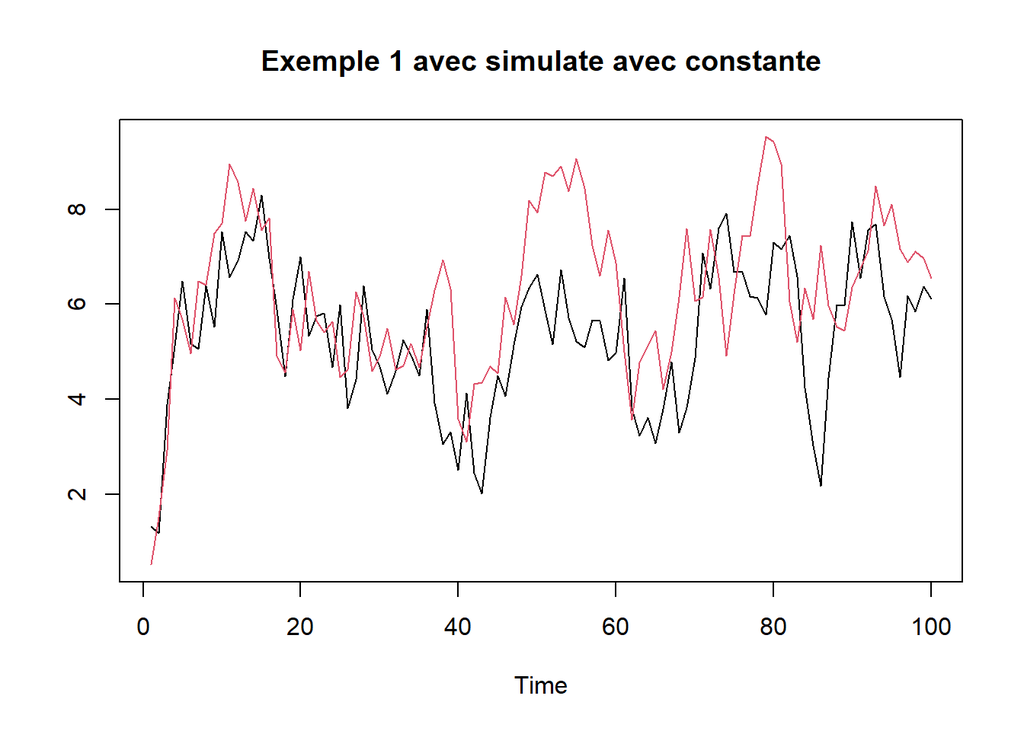

```r
ts.plot(vardat11, type="l", col=c(1,2),main="Exemple 1 avec simulate avec constante")
```

```r
# Avec corrélations sans constante
set.seed( 123456)
var12=ARMA(A=Apoly,B=B)
Cor=matrix(c(1,0.3,0.3,1),2,2)
w=rmnorm(n,mean=c(0,0),varcov=Cor) # simulation du bruit
varsim12= simulate(var12,sampleT = 100,noise=w)

vardat12=matrix(varsim12$output,nrow = 100,ncol=2)
head(vardat12)
```

```
##           [,1]        [,2]
## [1,] 0.8337332 -0.01321284
## [2,] 0.2259688  0.13445478
## [3,] 2.4373249  1.61101306
## [4,] 3.3407455  4.39627032
## [5,] 4.3860077  3.68947180
## [6,] 2.8119700  2.09835239
```

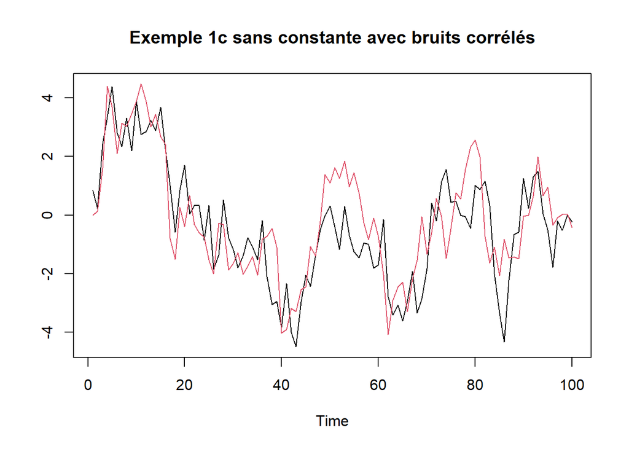

```r
colnames(vardat12)=c( "y1", "y2")
ts.plot(vardat12, type="l", col=c(1,2),main="Exemple 1c sans constante avec bruits corrélés")
```

```r
# Avec corrélations et constante
TRD=c(0.5,0.8)
set.seed( 123456)
var1c=ARMA(A=Apoly,B=B,TREND=TRD)
Cor=matrix(c(1,0.3,0.3,1),2,2)
w=rmnorm(n,mean=c(0,0),varcov=Cor) # simulation du bruit
varsim1c= simulate(var1c,sampleT = 100,noise=w)

vardat1c=matrix(varsim1c$output,nrow = 100,ncol=2)
head(vardat1c)
```

```
##          [,1]      [,2]
## [1,] 1.333733 0.7867872
## [2,] 1.235969 1.5944548
## [3,] 3.936325 3.6350131
## [4,] 5.294846 6.9128703
## [5,] 6.757198 6.6419118
## [6,] 5.562291 5.4392984
```

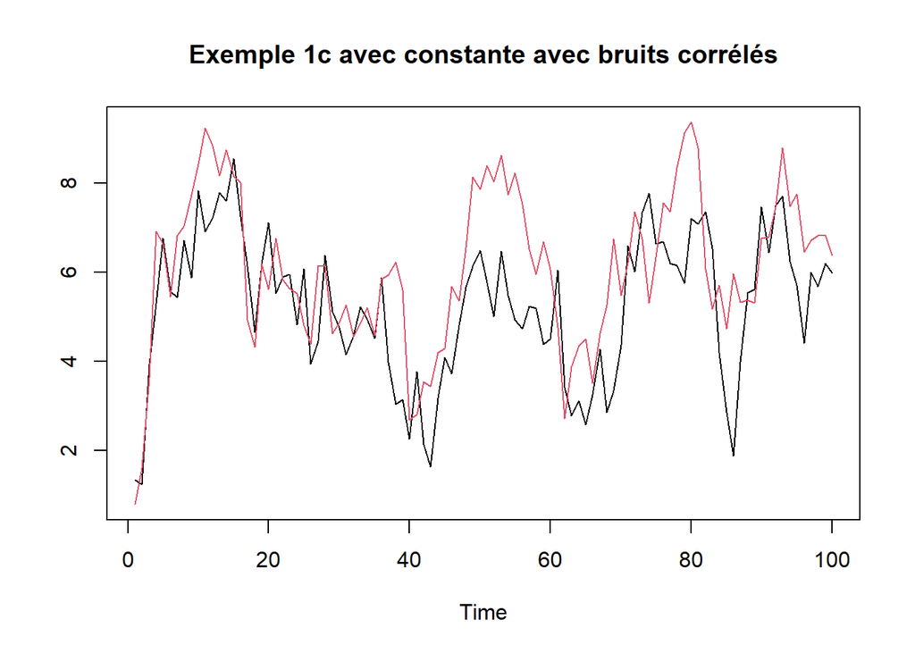

```r
colnames(vardat1c)=c( "y1", "y2")
ts.plot(vardat1c, type="l", col=c(1,2),main="Exemple 1c avec constante avec bruits corrélés")
```

L’écriture du processus sous la seconde forme permet de faire apparaître le “polynôme des retards”. En effet on nomme L l’opérateur défini par $L(X_{t})=X_{t-1}$ (qui est linéaire ). Par voie de conséquence on aura $L^{p}(X_{t})=X_{t-p}$ , à ce compte là on peut écrire
$$Id.X_{t}-\sum_{i=1}^{p} B_{i} X_{t-i}=B_{0}+\varepsilon_{t}=(Id-\sum_{i=1}^{p}B_{i}L^{i})X_{t}=B_{0}+\varepsilon_{t}$$

Ce polynôme retard interviendra lorsque nous aborderons la stationnarité des processus.

### Exemple d’un VAR(2)

$$\left[\begin{array}{l}y_{1} \\y_{2}\end{array}\right]_{t}=\left[\begin{array}{c}2 \\6
\end{array}\right]+\left[\begin{array}{cc}
0.4 & 0.2 \\
-0.2 & -0.4
\end{array}\right]\left[\begin{array}{l}
y_{1} \\
y_{2}
\end{array}\right]_{t-1}+\left[\begin{array}{cc}
-0.2 & 0.5 \\
-0.1 & 0.3
\end{array}\right]\left[\begin{array}{l}
y_{1} \\
y_{2}
\end{array}\right]_{t-2}+\left[\begin{array}{c}
\varepsilon_{1} \\
\varepsilon_{2}
\end{array}\right]_{t}$$

Nous introduisons dans ce modèle une corrélation entre les bruits blancs définie par la matrice $\left[\begin{array}{cc}1 & 0.3 \\0.3 & 1\end{array}\right]$

```r
Apoly2= array(c(1.0,-0.4,0.2,0,0.2,0.1,0,-0.2,-0.5,1,0.4,-0.3),c(3,2,2))
B = diag (2) # pas de moyennes mobiles
TRD=c(2,6)
n=500
var2=ARMA(A=Apoly2,B = B,TREND=TRD)
set.seed(123456)
Cor=matrix(c(1,0.3,0.3,1),2,2)
w=rmnorm(n,mean=c(0,0),varcov=Cor) # simulation du bruit
varsim2= simulate(var2,sampleT = n ,noise=w)
vardat2=matrix(varsim2$output,nrow = n,ncol=2)
colnames(vardat2)=c( "y1","y2")
head(vardat2)
```

```
##            y1       y2
## [1,] 2.833733 5.986787
## [2,] 3.975849 3.015496
## [3,] 8.872341 6.982996
## [4,] 8.970529 4.720493
## [5,] 9.417572 3.469295
## [6,] 6.030899 1.886383
```

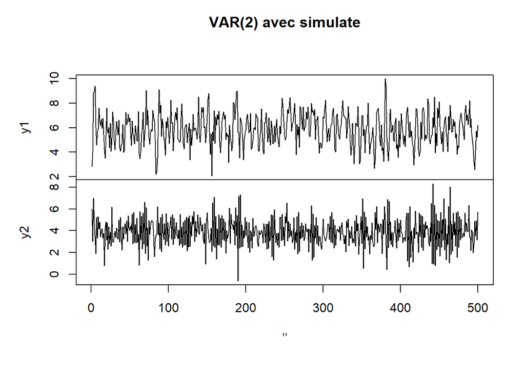

```r
plot.ts( vardat2,main ="VAR(2) avec simulate", xlab ="’’")
```

## Fonction VAR.sim de R

VAR.sim de la librairie tsDyn réalise également des simulations de modèles Var(p). La saisie des coefficients est assez proche de celle de notre fonction pédagogique, à savoir la matrice des coefficients relative à l’écriture
$$X_{t}=B_{0}+\sum_{i=1}^{p} B_{i} X_{t-i}+\varepsilon_{t}$$
; lag=p pour l’ordre du Var, la présence de la constante ou non est paramétrée par include =“const” ou “none”, le bruit blanc est “innov=”. Voici ce que donne notre premier Var(1)

```r
# sans constante
B1<-matrix(c(0.7, 0.2, 0.2, 0.7), 2,2)
set.seed(123456)
Cor=diag(2)
n=100
w=rmnorm(n,mean=c(0,0),varcov=Cor) # simulation du bruit
varsim1<-VAR.sim(B=B1,lag=1,n=100,include="none",innov=w)
head(varsim1)
```

```
##           [,1]        [,2]
## [1,] 0.8337332 -0.27604777
## [2,] 0.1734018  0.06100062
## [3,] 2.3858371  0.91184093
## [4,] 3.1648697  3.61810148
## [5,] 4.1072608  2.73947940
## [6,] 2.4268487  1.62513784
```

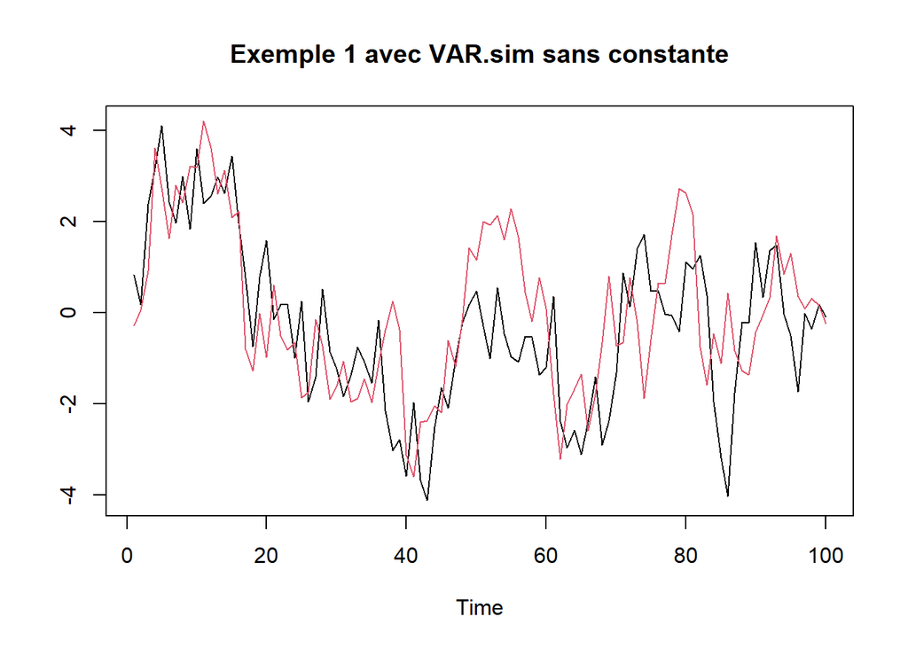

```r
ts.plot(varsim1, type="l", col=c(1,2),main="Exemple 1 avec VAR.sim sans constante")
```

```r
# avec constante
B1<-matrix(c(0.5,0.7, 0.2,0.8, 0.2, 0.7), 2,3,byrow=TRUE)
set.seed(123456)
Cor=diag(2)
n=100
w=rmnorm(n,mean=c(0,0),varcov=Cor) # simulation du bruit
varsim2<-VAR.sim(B=B1,lag=1,n,include="const",innov=w)
head(varsim2)
```

```
##          [,1]      [,2]
## [1,] 1.333733 0.5239522
## [2,] 1.183402 1.5210006
## [3,] 3.884837 2.9358409
## [4,] 5.118970 6.1347015
## [5,] 6.478451 5.6919194
## [6,] 5.177170 4.9660838
```

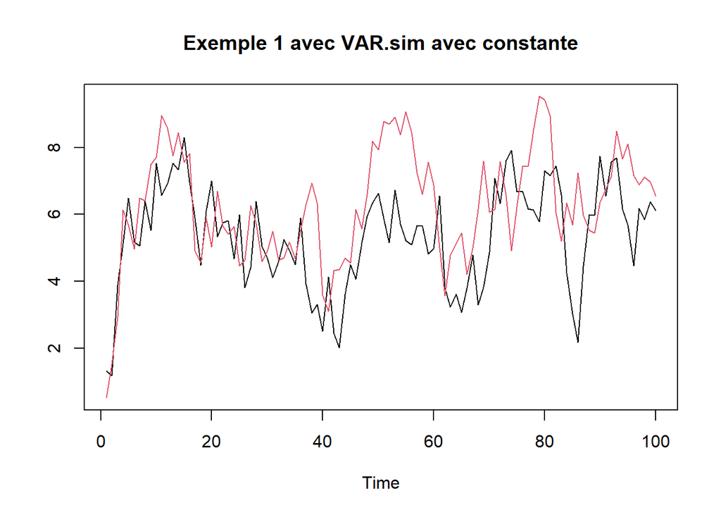

```r
ts.plot(varsim2, type="l", col=c(1,2),main="Exemple 1 avec VAR.sim avec constante")
```

```r
# Avec corrélations sans constante
B1<-matrix(c(0.7, 0.2, 0.2, 0.7), 2,2,byrow=TRUE)
set.seed(123456)
Cor=matrix(c(1,0.3,0.3,1),2,2)
w=rmnorm(n,mean=c(0,0),varcov=Cor) # simulation du bruit
n=100
varsim3<-VAR.sim(B=B1,lag=1,n,include="none",innov=w)
head(varsim3)
```

```
##           [,1]        [,2]
## [1,] 0.8337332 -0.01321284
## [2,] 0.2259688  0.13445478
## [3,] 2.4373249  1.61101306
## [4,] 3.3407455  4.39627032
## [5,] 4.3860077  3.68947180
## [6,] 2.8119700  2.09835239
```

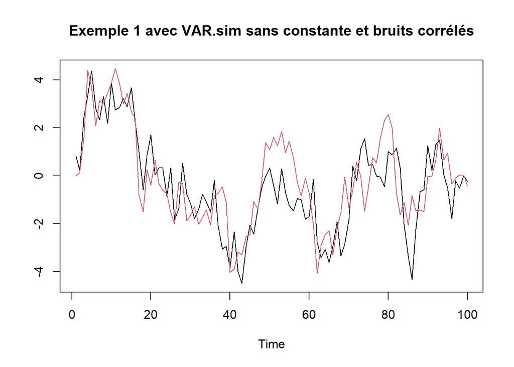

```r
ts.plot(varsim3, type="l", col=c(1,2),main="Exemple 1 avec VAR.sim sans constante et bruits corrélés")
```

```r
# Avec corrélations et constante
B1<-matrix(c(0.5,0.7, 0.2,0.8, 0.2, 0.7), 2,3,byrow=TRUE)
set.seed(123456)
Cor=matrix(c(1,0.3,0.3,1),2,2)
w=rmnorm(n,mean=c(0,0),varcov=Cor) # simulation du bruit
n=100
w=rmnorm(n,mean=c(0,0),varcov=Cor) # simulation du bruit
varsim4<-VAR.sim(B=B1,lag=1,n,include="const",innov=w)
head(varsim4)
```

```
##            [,1]      [,2]
## [1,] -0.6205531 0.4043809
## [2,]  0.8606308 1.9106364
## [3,]  3.4682744 3.7453634
## [4,]  2.5243017 4.2993317
## [5,]  3.3952355 5.6044299
## [6,]  2.0892294 5.2863681
```

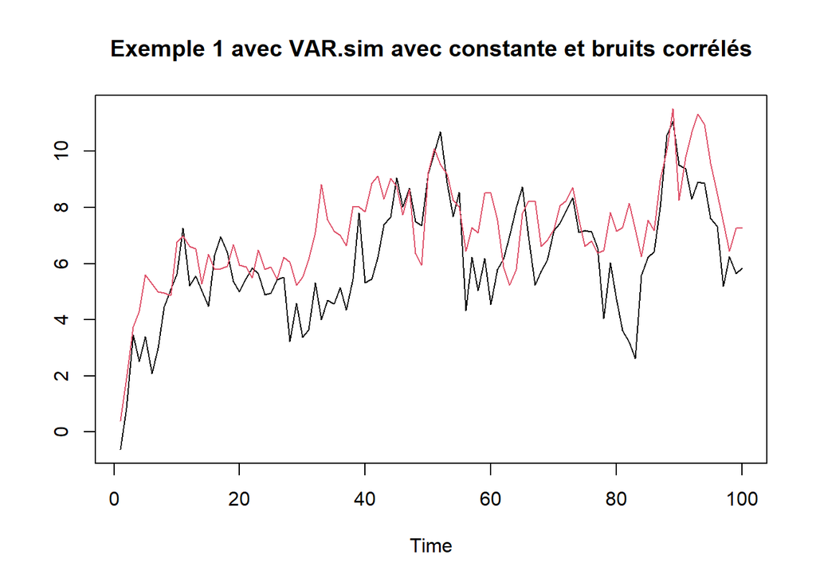

```r
ts.plot(varsim4, type="l", col=c(1,2),main="Exemple 1 avec VAR.sim avec constante et bruits corrélés")
```

En introduisant la constante pour le Var(2)

```r
B2<-rbind(c(2, 0.4, 0.2,-0.2,0.5), c(6, -0.2, -0.4,-0.1,0.3))
Cor=matrix(c(1,0.3,0.3,1),2,2)
w=rmnorm(500,mean=c(0,0),varcov=Cor) # simulation du bruit
set.seed(123456)
varsim22 <- VAR.sim(B=B2,n=500, lag=2,include="const",innov=w )
head(varsim22)
```

```
##          [,1]     [,2]
## [1,] 2.247382 6.427718
## [2,] 4.978878 3.228442
## [3,] 7.034358 3.870823
## [4,] 6.503276 4.190120
## [5,] 6.512749 2.397409
## [6,] 7.079461 3.438486
```

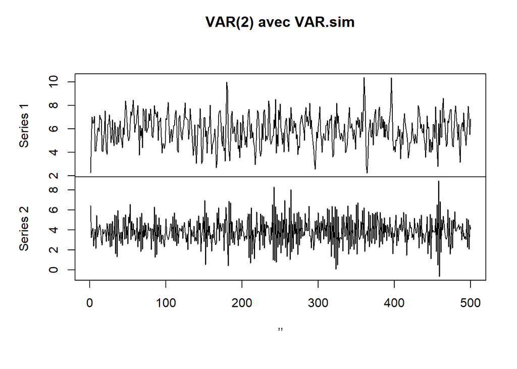

```r
plot.ts( varsim22,main ="VAR(2) avec VAR.sim", xlab ="’’")
```

# SECONDE PARTIE

## Stationnarité

On rappelle qu’un processus est stationnaire (faiblement ou de second ordre) si et seulement si:
$$E\left[X_{t}\right]=\mu, \forall t \in \mathbb{Z}$$
$$E\left[X_{t} X_{t}^{\prime}\right]<\infty, \forall t \in \mathbb{Z}$$
$$E\left[\left(X_{t}-\boldsymbol{\mu}\right)\left(X_{t-h}-\boldsymbol{\mu}\right)^{\prime}\right]=\Gamma_{X}(h)=\Gamma_{X}^{\prime}(-h), \quad \forall t \in \mathbb{Z} \text { et } h=0,1, \ldots$$
La dernière ligne de la définition exprime que la matrice des covariances des composantes est indépendante de t.

Les termes de cette matrice sont $\gamma_{i j}(h)$ les fonctions d’autocorrélation des $y_{i}$ si $i=j$ et les fonctions d’autocorrélation croisées entre $y_{i}$ et $y_{j}$.
$$\gamma_{i j}(h)=\operatorname{Cov}\left(y_{i t}, y_{j, t-h}\right), \forall i \forall j$$

Attention, cette définition est valable pour tous les types de processus. Pour un VAR(p) la stationnarité fera l’objet d’une propriété spécifique, qui évitera le recours à cette définition générale pas toujours facile à manipuler.

Il apparaît clairement que si le processus vectoriel est stationnaire les composantes le sont. Visuellemnt si on constate au moins une composante non stationnaire, le processus ne l’est pas (on disposera d’une batterie de tests). La réciproque est fausse, donc éviter de conclure hâtivement en voyant les graphiques de chaque composante. Voici un contrexemple:
$$y_{t}=\left\{\begin{array}{lcc}
y_{1, t} & = & \varepsilon_{1, t} \\
y_{2, t} & = & \varepsilon_{2, t}+(-1)^{t} \varepsilon_{1, t}
\end{array}\right.$$
Il est clair que chaque composante est stationnaire: Leurs espérances sont nulles, donc indépendantes de t et,
$$\gamma_{y_{1}}(h)=Cov(y_{1,t},y_{1,t-h})=E(y_{1,t}.y_{1,t-h})=E(\epsilon_{1,t}.\epsilon_{1,t-h})=\gamma_{\epsilon_{1}}(h)$$
qui ne dépend pas de t, puisque $\epsilon_{1,t}$ est bruit blanc (donc stationnaire). De même,
$$\operatorname{Cov}\left(y_{2, t+h}, y_{2, t}\right)=E\left[y_{2, t+h} y_{2, t}\right]=E\left[\left(\varepsilon_{2, t+h}+(-1)^{t+h} \varepsilon_{1, t+h}\right)\left(\varepsilon_{2, t}+(-1)^{t} \varepsilon_{1, t}\right)\right]=\gamma_{\varepsilon_{2}}(h)+(-1)^{h} \gamma_{\varepsilon_{1}}(h)$$
On peut constater visuellement la stationnarité des séries sur le graphique ci-dessous.

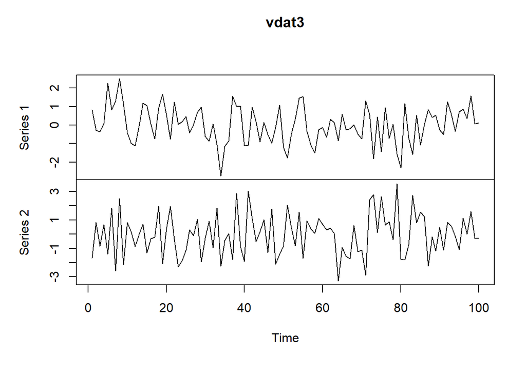

```r
set.seed(123456)
w = matrix(rnorm(200),nrow = 100,ncol=2)
y1=w[,1]
y2=w[,2]+rep(c(-1,1),50)*y1
vdat3=matrix(c(y1,y2),nrow=100)
plot.ts(vdat3,type="l",col=c(1,2))
```

Mais le processus bivarié n’est pas stationnaire…!
$$\operatorname{Cov}\left(y_{2, t+h}, y_{1, t}\right)=E\left[y_{2, t+h} y_{1, t}\right]=E\left[\left(\varepsilon_{2, t+h}+(-1)^{t+h} \varepsilon_{1, t+h}\right)\left( \varepsilon_{1, t}\right)\right]=(-1)^{t+h} \gamma_{\varepsilon_{1}}(h)$$
qui est un terme dépendant de t. En terminant tous les calculs de la matrice des covariances on a:
$$\Gamma_{h,t}=\left[\begin{array}{cc}
\gamma_{\varepsilon_{1}(h)} & (-1)^{t} \gamma_{\varepsilon_{1}(h)} \\
(-1)^{t+h} \gamma_{\varepsilon_{1}(h)} & \left.\gamma_{\varepsilon_{2}(h)}+(-1)^{h}\right) \gamma_{\varepsilon_{1}(h)}
\end{array}\right]$$
qui dépend de t.

# Stationnarité d’un VAR(p)

## Cas d’un VAR(1)

Ce que nous venons d’étudier pour une série simple se transpose aisément au cas d’un VAR(1) multivarié. $X_{t}$ et $\epsilon_{t}$ sont des vecteurs se dimension N, et a devient une matrice A $N\times N$. Si on note encore L l’opérateur retard, le processus est caractérisé par:
$$(1-AL)X_{t}=\epsilon_{t}$$
La condition d’inversibilité est $||AL||<1$, donc $||A||<1$. Dans la théorie des espaces vectoriels normés la norme d’une matrice (parmi d’autres normes !) est le module de sa plus grande valeur propre. D’où le résultat:
*Un processus Var(1) $(1-AL)X_{t}=\epsilon_{t}$ est stable si A a toutes ses valeurs propres en module strictement inférieures à 1*

N.B: Le lecteur attentif aura remarqué que nous disons “stable” et non plus “stationnaire”. En effet il existe des processus multivariés avec des valeurs propres de A supérieurs à 1 mais stationnaires faiblement (ou du second ordre).

## Cas d’un VAR(p)

On travaille maintenant sur un processus de K variables du type:
$$y_{t}=\nu+A_{1} y_{t-1}+A_{2} y_{t-2}+\cdots+A_{p} y_{t-p}+u_{t}, \quad t \in \mathbb{Z}$$
On va, par un procédé analogue à celui qui nous permettait de transformer une équation différentielle d’ordre p en un sytème différentiel d’ordre 1, se rammener à un VAR(1).
On pose:
$$Y_{t}=\left[\begin{array}{c}
y_{t} \\
y_{t-1} \\
\vdots \\
y_{t-p+1}
\end{array}\right]$$
$$\mathbf{C}=\left[\begin{array}{c}
\nu \\
0 \\
\vdots \\
0
\end{array}\right]$$
$$\mathbf{U}_{t}=\left[\begin{array}{c}
u_{t} \\
0 \\
\vdots \\
0
\end{array}\right]$$
et
$$\mathbf{A}=\left[\begin{array}{ccccc}
A_{1} & A_{2} & \cdots & A_{p-1} & A_{p} \\
I_{K} & 0 & \ldots & 0 & 0 \\
0 & I_{K} & \ddots & 0 & 0 \\
\vdots & \ddots & \ddots & \ddots & \vdots \\
0 & 0 & \ldots & I_{K} & 0
\end{array}\right]$$

Attention $y_{t},\nu, u_{t}, 0$ sont déjà des vecteurs colonnes de dimension K; A est une matrice de dimension (K.p)² (matrice dite “par blocs”) qui est appelée “MATRICE COMPAGNON du processus” A ce prix on obtient une écriture équivalente:
$$Y_{t}=\mathbf{C}+\mathbf{A} Y_{t-1}+\mathbf{U}_{t}, t \in \mathbb{Z}$$
**CONCLUSION: Le processus est stable si les valeurs propres de la marice compagnon sont strictement inférieures à 1.**

### Exemple

Dans un premier temps nous créons une fonction qui retourne la matrice compagnon d’un VAR(p) simulé par VAR.sim.

```r
companion=function(B) {
N=nrow(B)
C=ncol(B)
if(floor(C/N)==C/N) { p=C/N ; BB=B} else # detection d'une constante
{ p=floor(C/N)
BB=B[,2:C]  # si constante
}
return(rbind(BB,cbind(diag(N*(p-1)),matrix(0,nrow=N*(p-1),ncol=N))))
}
```

Appliquons la au VAR(2)

```r
COMP=companion(B2)
print(COMP)
```

```
##      [,1] [,2] [,3] [,4]
## [1,]  0.4  0.2 -0.2  0.5
## [2,] -0.2 -0.4 -0.1  0.3
## [3,]  1.0  0.0  0.0  0.0
## [4,]  0.0  1.0  0.0  0.0
```

```r
x=eigen(COMP,only.values=T)$values
print("Modules des valeurs propres")
```

```
## [1] "Modules des valeurs propres"
```

```r
print(sapply(x,abs),quote=F,digits=3)
```

```
## [1] 0.7980 0.6263 0.6263 0.0319
```

Elles n’excèdent pas 0.7980 , le processus VAR(2) est donc stable.

On a pu ici les calculer exactement, car le processus est “préfabriqué”. Dans la réalité nous traiterons de processus ajustés sur des séries réelles, ce qui confèrera un caractère aléatoire à ces valeurs propres. Leur loi de probabilité étant déterminée ( Dickey et Fuller) on pourra tester l’hypothèse nulle “une au moins des valeurs propres a un module égal à 1” contre l’hypothèse alternative “tous les modules sont inférieurs à 1”.

Dans la littérature on lit souvent l’expression “racines unitaires” (“units roots”), de quoi s’agit-t-il?
Lorsqu’on calcule les valeurs propres de A, la matrice compagnon, on résoud l’équation:
$$det(A-\lambda.Id)=0$$
Avec un peu d’algèbre linéaire et une manipulation de matrices par blocs on montre que l’équation ci-dessus est équivalante à
$$\operatorname{det}\left(\lambda^{p}.Id-A_{1} \lambda^{p-1}-A_{2} \lambda^{p-2}-\cdots-A_{p}\right)=0$$
Mais les statisticiens préfèrent que les exposants soient identiques aux indices, ce qui revient à poser
$$\lambda=\frac{1}{z}$$
ce qui donne:
$$\operatorname{det}\left(Id-A_{1} z-A_{2} z^{2}-\cdots-A_{p} z^{p}\right)=0$$
les solutions de cettes équations devant vérifier $|z|>1$ .

## Tests de stationnarité

Au vu de ce qui précède, si une au moins des variables incluses dans le VAR n’est pas stationnaire, le VAR ne le sera pas. Donc il va s’agir de contrôler la stationnarité de chaque variable qu’on veut inclure dans le modèle VAR. Avant d’aborder les tests de stationnarité nous ferons un détour pour distinguer deux types de NON-stationnarité d’un processus univarié (ou d’une série univariée).

### non stationnarité déterministe

C’est le cas où le processus est de la forme:
$$X_{t}=f(t)+Z_{t}$$
où $Z_{t}$ est stationnaire et f fonction vectorielle. Pour stationnariser un tel processus, il suffit de lui soustraire la tendance déterministe. Cette tendance est souvent $f(t)=a+bt$ ou $f(t)=a+bt+ct^{2}$
$X_{t}$ est appelé dans la littérature “trend-stationary process” ou plus simplement TS.

Nous allons développer un exemple. Nous simulons le processus :
$$X_{t}=0.7X_{t-1}+5+0.05t+\epsilon_{t}$$
Attention, il n’est pas a priori de la forme trend-stationary process. Nous en traçons une réalisation sur 100 valeurs, qui va suggérer un trend affine f(t), que nous allons estimer par régression de moindres carrés, et retrancher f(t) estimé au processus initial. Le résultat semble stationnaire, ce que nous vérifierons plus loin avec des tests adaptés.

```r
set.seed(123456)
B4<-matrix(c(5,0.05, 0.7),nrow=1)
vdat4=var(100,B=B4,lag=1,mod="trend") # revoir le cas de dim=1 dans la fonction
ts.plot(vdat4,type="l",col=c(1))

lm=lm(vdat4~c(1:100))
lm
```

```
##
## Call:
## lm(formula = vdat4 ~ c(1:100))
##
## Coefficients:
## (Intercept)     c(1:100)
##     15.6336       0.1723
```

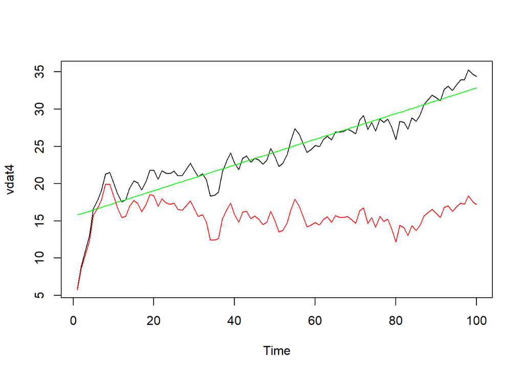

```r
lines(lm$fitted.values,col="green")
lines(lm$residuals+15.6336,col="red")
```

### Non stationnarité stochastique

$X_{t}$ est caractérisé par le fait que le processus différencié $X_{t}-X_{t-1}$ est stationnaire.
$$(1-L) Y_{t}=Z_{t}\;stationnaire$$
Simulons l’exemple $Y{t}=Y_{t-1}+0.3+\epsilon_{t}$ (marche aléatoire avec dérive 0.3)

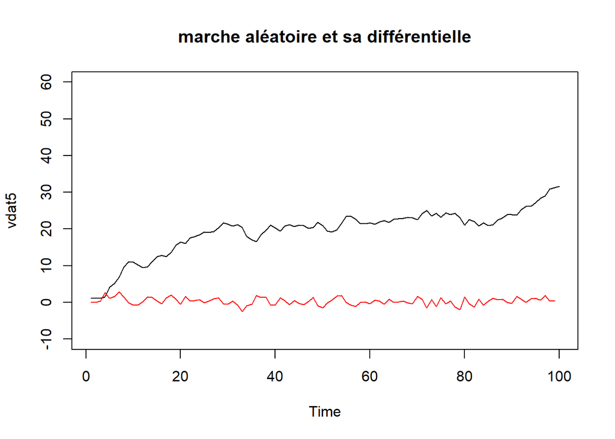

```r
set.seed(123456)
B5<-matrix(c(0.3, 1),nrow=1)
vdat5=var(100,B=B5,lag=1,mod="const")
ts.plot(vdat5,type="l",col=c(1),ylim=c(-10,60),main="marche aléatoire et sa différentielle")

diff_vdat5=diff(vdat5,lag=1,differences=1)
lines(diff_vdat5,col="red")
```

Un tel processus est nommé processus DS (Difference stationnary), ou processus intégré d’ordre 1 ( I(1)).
S’il faut différencier d fois avant la stationnarité on dit à ce moment là processus I(d). Ce qui s’écrit:
$$(1-L)^{d} Y_{t}=Z_{t}$$
Le polynôme retard $(1-L)^d$ a 1 comme racine d’ordre d (ou d racines unitaires).

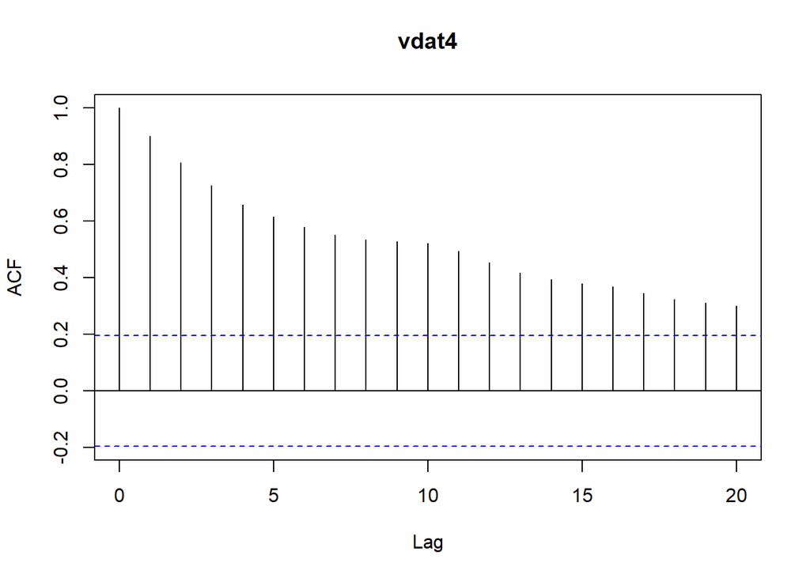

```r
acf(vdat4,main="vdat4")
```

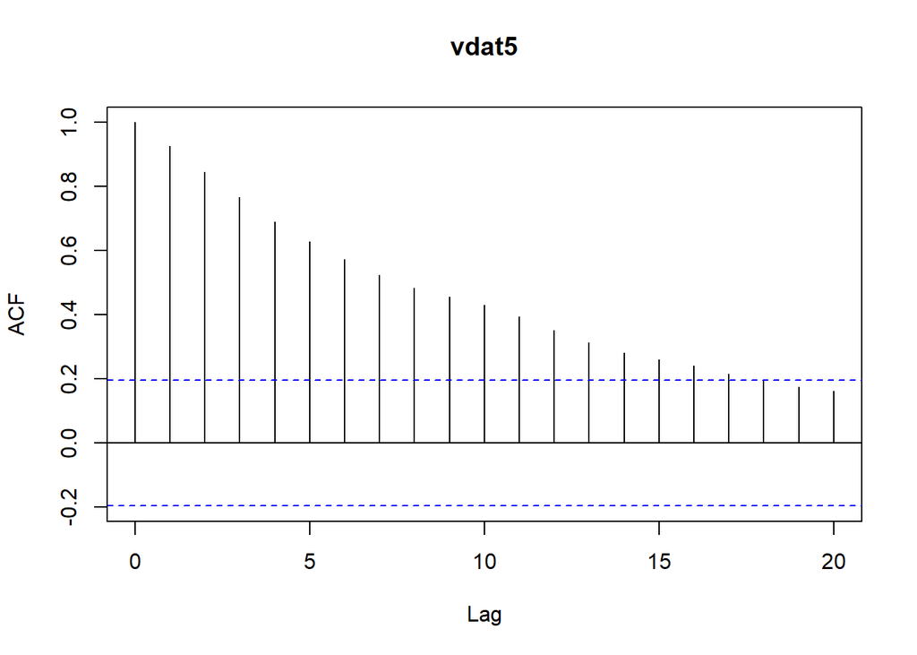

```r
acf(vdat5,main="vdat5")
```

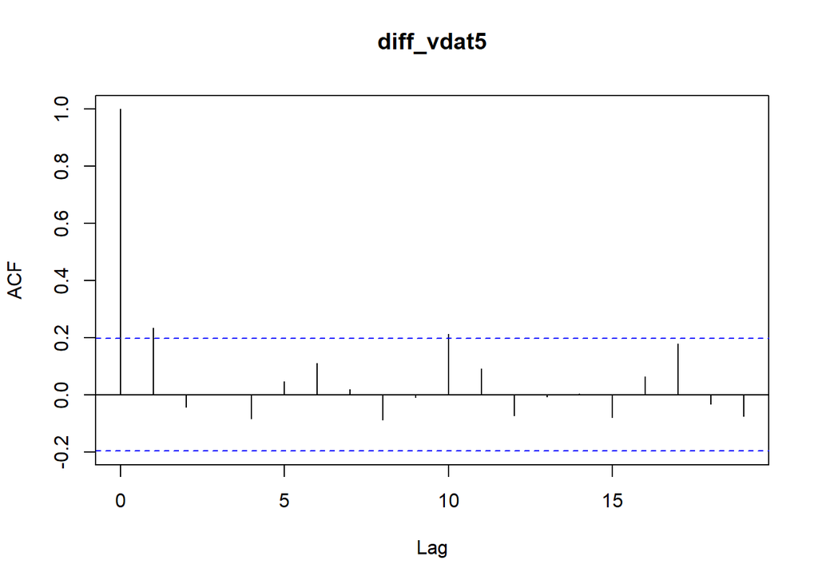

```r
acf(diff_vdat5,main="diff_vdat5")
```

### Test de Dickey-Fuller

L’hypothèse nulle H0 est la présence de racines unitaires (donc de NON stationnarité de type DS). Le test va s’appliquer à une série univariée. La fonction utilisée par R est “ur.df” de la librairie “urca”. L’existence de racines unitaires va être testée dans trois modèles différents:

$$\Delta Y_{t}=\rho Y_{t-1}+\alpha+\beta t+\sum_{j=1}^{p} \phi_{j} \Delta Y_{t-j}+\varepsilon_{t}\;\;\;(modèle\:1)$$
$$\Delta Y_{t}=\rho Y_{t-1}+\alpha+\sum_{j=1}^{p} \phi_{j} \Delta Y_{t-j}+\varepsilon_{t}\;\;\;(modèle\:2)$$
$$\Delta Y_{t}=\rho Y_{t-1}+\sum_{j=1}^{p} \phi_{j} \Delta Y_{t-j}+\varepsilon_{t}\;\;\;(modèle\:3)$$
Il s’agit donc de vérifier la significativité des coefficients $\rho,\alpha,\beta$ comme avec le test de Student, mais avec des valeurs critiques différentes référencées dans les tables de Dickey-Fuller.
L’hypothèse nulle H0 est; $\rho =0$ contre H1; $\rho <0$ , donc une zone de rejet à GAUCHE. Pour $\alpha,\beta$ c’est leur valeur absolue qui est testée, donc zone de rejet à DROITE.

#### premier exemple

$$Y{t}=10+0.5t+0.7Y_{t-1}+\epsilon_{t}$$
série AR(1) avec trend et constante.

```r
set.seed(123456)
B2<-matrix(c(10,0.5,0.7),nrow=1)
vdat6=var(100,B=B2,lag=1,mod="trend")

summary(ur.df(vdat6,type="trend",lags=4))
```

```
##
## ###############################################
## # Augmented Dickey-Fuller Test Unit Root Test #
## ###############################################
##
## Test regression trend
##
##
## Call:
## lm(formula = z.diff ~ z.lag.1 + 1 + tt + z.diff.lag)
##
## Residuals:
##     Min      1Q  Median      3Q     Max
## -2.4813 -0.7414  0.0198  0.6743  1.7676
##
## Coefficients:
##             Estimate Std. Error t value Pr(>|t|)
## (Intercept) 11.06179    2.13450   5.182 1.38e-06 ***
## z.lag.1     -0.33208    0.07399  -4.488 2.17e-05 ***
## tt           0.55101    0.12295   4.482 2.22e-05 ***
## z.diff.lag1  0.25485    0.09266   2.750  0.00723 **
## z.diff.lag2 -0.03609    0.09311  -0.388  0.69926
## z.diff.lag3  0.10667    0.09136   1.168  0.24611
## z.diff.lag4 -0.04387    0.08195  -0.535  0.59374
## ---
## Signif. codes:  0 '***' 0.001 '**' 0.01 '*' 0.05 '.' 0.1 ' ' 1
##
## Residual standard error: 0.9708 on 88 degrees of freedom
## Multiple R-squared:  0.2215, Adjusted R-squared:  0.1685
## F-statistic: 4.174 on 6 and 88 DF,  p-value: 0.0009717
##
##
## Value of test-statistic is: -4.4881 19.7753 10.082
##
## Critical values for test statistics:
##       1pct  5pct 10pct
## tau3 -4.04 -3.45 -3.15
## phi2  6.50  4.88  4.16
## phi3  8.73  6.49  5.47
```

Nous obtenons dans la colonne Estimate les valeurs estimées des coefficients avec leurs significativités signalées par les *** . Intercept et tt pour constante et trend, et z.lag.1 pour rho..les autres coefficients sont peu significatifs, ce qui implique qu’on refera le test avec lag=1.

```r
summary(ur.df(vdat6,type="trend",lags=1))
```

```
##
## ###############################################
## # Augmented Dickey-Fuller Test Unit Root Test #
## ###############################################
##
## Test regression trend
##
##
## Call:
## lm(formula = z.diff ~ z.lag.1 + 1 + tt + z.diff.lag)
##
## Residuals:
##      Min       1Q   Median       3Q      Max
## -2.54547 -0.76306  0.06234  0.75194  2.08220
##
## Coefficients:
##             Estimate Std. Error t value Pr(>|t|)
## (Intercept)  9.44874    1.33501   7.078 2.61e-10 ***
## z.lag.1     -0.27217    0.04421  -6.157 1.82e-08 ***
## tt           0.45131    0.07403   6.096 2.38e-08 ***
## z.diff.lag   0.19797    0.07801   2.538   0.0128 *
## ---
## Signif. codes:  0 '***' 0.001 '**' 0.01 '*' 0.05 '.' 0.1 ' ' 1
##
## Residual standard error: 0.9759 on 94 degrees of freedom
## Multiple R-squared:  0.3969, Adjusted R-squared:  0.3777
## F-statistic: 20.62 on 3 and 94 DF,  p-value: 2.379e-10
##
##
## Value of test-statistic is: -6.1567 28.8082 19.5632
##
## Critical values for test statistics:
##       1pct  5pct 10pct
## tau3 -4.04 -3.45 -3.15
## phi2  6.50  4.88  4.16
## phi3  8.73  6.49  5.47
```

Les conclusions sont irrévocables: -6.1567 donc H0 racine unitaire rejetée, 28.8 H01 racine unitaire ET trend nul rejeté, 19.56 H02 racine unitaie ET trend nul ET constante nulle rejeté. Il faut avouer que la lecture des coefficients nous donne une vision claire du modèle: pas de racine unitaire, un trend ET une constante significatifs, donc STATONNAIRE AUTOUR D’UN TREND.

Voyons le modèle 2 sans trend. Mais volontairement testons un modèle de type avec trend.

$$Y{t}=5++0.7Y_{t-1}+\epsilon_{t}$$

```r
set.seed(123456)
B2<-matrix(c(5,0.7),nrow=1)
vdat7=var(100,B=B2,lag=1,mod="const")

summary(ur.df(vdat7,type="trend",lags=1))
```

```
##
## ###############################################
## # Augmented Dickey-Fuller Test Unit Root Test #
## ###############################################
##
## Test regression trend
##
##
## Call:
## lm(formula = z.diff ~ z.lag.1 + 1 + tt + z.diff.lag)
##
## Residuals:
##      Min       1Q   Median       3Q      Max
## -2.56229 -0.75099  0.04119  0.72295  2.11446
##
## Coefficients:
##              Estimate Std. Error t value Pr(>|t|)
## (Intercept)  4.958095   0.925671   5.356 6.01e-07 ***
## z.lag.1     -0.289464   0.055009  -5.262 8.94e-07 ***
## tt          -0.002926   0.003512  -0.833   0.4070
## z.diff.lag   0.218726   0.086587   2.526   0.0132 *
## ---
## Signif. codes:  0 '***' 0.001 '**' 0.01 '*' 0.05 '.' 0.1 ' ' 1
##
## Residual standard error: 0.9757 on 94 degrees of freedom
## Multiple R-squared:  0.2642, Adjusted R-squared:  0.2407
## F-statistic: 11.25 on 3 and 94 DF,  p-value: 2.255e-06
##
##
## Value of test-statistic is: -5.2621 9.5913 14.1441
##
## Critical values for test statistics:
##       1pct  5pct 10pct
## tau3 -4.04 -3.45 -3.15
## phi2  6.50  4.88  4.16
## phi3  8.73  6.49  5.47
```

tt n’a aucune significativité. On n’est donc pas dans le bon modèle, et on teste le modèle 2 .

```r
summary(ur.df(vdat7,type="drift",lags=1))
```

```
##
## ###############################################
## # Augmented Dickey-Fuller Test Unit Root Test #
## ###############################################
##
## Test regression drift
##
##
## Call:
## lm(formula = z.diff ~ z.lag.1 + 1 + z.diff.lag)
##
## Residuals:
##      Min       1Q   Median       3Q      Max
## -2.50069 -0.68439  0.06441  0.74197  2.23124
##
## Coefficients:
##             Estimate Std. Error t value Pr(>|t|)
## (Intercept)  4.80068    0.90471   5.306 7.30e-07 ***
## z.lag.1     -0.28895    0.05492  -5.262 8.82e-07 ***
## z.diff.lag   0.22779    0.08576   2.656  0.00927 **
## ---
## Signif. codes:  0 '***' 0.001 '**' 0.01 '*' 0.05 '.' 0.1 ' ' 1
##
## Residual standard error: 0.9741 on 95 degrees of freedom
## Multiple R-squared:  0.2588, Adjusted R-squared:  0.2431
## F-statistic: 16.58 on 2 and 95 DF,  p-value: 6.656e-07
##
##
## Value of test-statistic is: -5.2615 14.0855
##
## Critical values for test statistics:
##       1pct  5pct 10pct
## tau2 -3.51 -2.89 -2.58
## phi1  6.70  4.71  3.86
```

Et enfin pour être exhaustif nous simulons un processus avec racine unitaire ET constante ET trend.
$$Y{t}=10+0.5t+1Y_{t-1}+\epsilon_{t}$$

```r
set.seed(123456)
B2<-matrix(c(10,0.5,1),nrow=1)
vdat8=var(100,B=B2,lag=1,mod="trend")

summary(ur.df(vdat8,type="trend",lags=1))
```

```
##
## ###############################################
## # Augmented Dickey-Fuller Test Unit Root Test #
## ###############################################
##
## Test regression trend
##
##
## Call:
## lm(formula = z.diff ~ z.lag.1 + 1 + tt + z.diff.lag)
##
## Residuals:
##      Min       1Q   Median       3Q      Max
## -2.49238 -0.68497  0.06999  0.68156  1.83998
##
## Coefficients:
##              Estimate Std. Error t value Pr(>|t|)
## (Intercept) 9.8000750  1.1461503   8.550 2.21e-13 ***
## z.lag.1     0.0014312  0.0005668   2.525   0.0132 *
## tt          0.3710515  0.0486763   7.623 1.96e-11 ***
## z.diff.lag  0.1496815  0.1014739   1.475   0.1435
## ---
## Signif. codes:  0 '***' 0.001 '**' 0.01 '*' 0.05 '.' 0.1 ' ' 1
##
## Residual standard error: 0.9516 on 94 degrees of freedom
## Multiple R-squared:  0.9956, Adjusted R-squared:  0.9955
## F-statistic:  7104 on 3 and 94 DF,  p-value: < 2.2e-16
##
##
## Value of test-statistic is: 2.5252 25.3679 34.9433
##
## Critical values for test statistics:
##       1pct  5pct 10pct
## tau3 -4.04 -3.45 -3.15
## phi2  6.50  4.88  4.16
## phi3  8.73  6.49  5.47
```

H0 racine unitaire non rejetée, nullité des deux autres coefficients rejetée, donc racine unitaire avec trend et constante.

## Estimation d’un modèle VAR

Nous allons commencer par étudier un processus simulé. Par exemple VAR(2) sera notre base de données.

### première étape: s’assurer de la stationnarité des composantes.

```r
vardat2.train=vardat2[1:450,]
summary(ur.df(vardat2.train[,"y1"],type="drift",lags=1))
```

```
##
## ###############################################
## # Augmented Dickey-Fuller Test Unit Root Test #
## ###############################################
##
## Test regression drift
##
##
## Call:
## lm(formula = z.diff ~ z.lag.1 + 1 + z.diff.lag)
##
## Residuals:
##     Min      1Q  Median      3Q     Max
## -4.0659 -0.8507  0.0122  0.8229  3.3407
##
## Coefficients:
##             Estimate Std. Error t value Pr(>|t|)
## (Intercept)  4.23293    0.30372  13.937  < 2e-16 ***
## z.lag.1     -0.71823    0.05076 -14.151  < 2e-16 ***
## z.diff.lag   0.19871    0.04631   4.291 2.19e-05 ***
## ---
## Signif. codes:  0 '***' 0.001 '**' 0.01 '*' 0.05 '.' 0.1 ' ' 1
##
## Residual standard error: 1.2 on 445 degrees of freedom
## Multiple R-squared:  0.3274, Adjusted R-squared:  0.3244
## F-statistic: 108.3 on 2 and 445 DF,  p-value: < 2.2e-16
##
##
## Value of test-statistic is: -14.1507 100.1386
##
## Critical values for test statistics:
##       1pct  5pct 10pct
## tau2 -3.44 -2.87 -2.57
## phi1  6.47  4.61  3.79
```

```r
summary(ur.df(vardat2.train[,"y2"],type="drift",lags=1))
```

```
##
## ###############################################
## # Augmented Dickey-Fuller Test Unit Root Test #
## ###############################################
##
## Test regression drift
##
##
## Call:
## lm(formula = z.diff ~ z.lag.1 + 1 + z.diff.lag)
##
## Residuals:
##     Min      1Q  Median      3Q     Max
## -4.2460 -0.6600  0.0251  0.6487  2.8989
##
## Coefficients:
##             Estimate Std. Error t value Pr(>|t|)
## (Intercept)  4.42597    0.31622  13.996  < 2e-16 ***
## z.lag.1     -1.14426    0.08071 -14.177  < 2e-16 ***
## z.diff.lag  -0.26951    0.04556  -5.915 6.62e-09 ***
## ---
## Signif. codes:  0 '***' 0.001 '**' 0.01 '*' 0.05 '.' 0.1 ' ' 1
##
## Residual standard error: 1.044 on 445 degrees of freedom
## Multiple R-squared:  0.799,  Adjusted R-squared:  0.7981
## F-statistic: 884.5 on 2 and 445 DF,  p-value: < 2.2e-16
##
##
## Value of test-statistic is: -14.1774 100.5007
##
## Critical values for test statistics:
##       1pct  5pct 10pct
## tau2 -3.44 -2.87 -2.57
## phi1  6.47  4.61  3.79
```

### recherche d’un décalage adapté.

```r
lag=lags.select(vardat2.train,lag.max =4,include="const")
print(lag)
```

```
## Best AIC:  lag= 2
## Best BIC:  lag= 2
## Best HQ :  lag= 2
```

Nous choisissons un VAR(2)

### estimation du modèle.

```r
library(vars)
varest2= VAR(vardat2.train,p = 2,type ="const",season = NULL,exogen = NULL)
print(varest2)
```

```
##
## VAR Estimation Results:
## =======================
##
## Estimated coefficients for equation y1:
## =======================================
## Call:
## y1 = y1.l1 + y2.l1 + y1.l2 + y2.l2 + const
##
##      y1.l1      y2.l1      y1.l2      y2.l2      const
##  0.3817216  0.2438594 -0.1905000  0.5458531  1.7083422
##
##
## Estimated coefficients for equation y2:
## =======================================
## Call:
## y2 = y1.l1 + y2.l1 + y1.l2 + y2.l2 + const
##
##      y1.l1      y2.l1      y1.l2      y2.l2      const
## -0.2304450 -0.3668646 -0.1320860  0.3427808  6.0924379
```

Nous y retrouvons une estimation correcte des coefficients du VAR(2) initial.

On peut contôler la stabilité du modèle estimé par la fonction “roots”

```r
roots=roots(varest2)
roots
```

```
## [1] 0.81023568 0.66947378 0.66947378 0.01872492
```

### tests sur les résidus

D’abord tester l’absence d’autocorrélations sur les résidus (Test dit du “Portementeau”) adapté aux séries multivariées (“serial.test”)

```r
var.test2= serial.test(varest2,lags.pt =16,type ="PT.asymptotic")
var.test2
```

```
##
##  Portmanteau Test (asymptotic)
##
## data:  Residuals of VAR object varest2
## Chi-squared = 61.485, df = 56, p-value = 0.2861
```

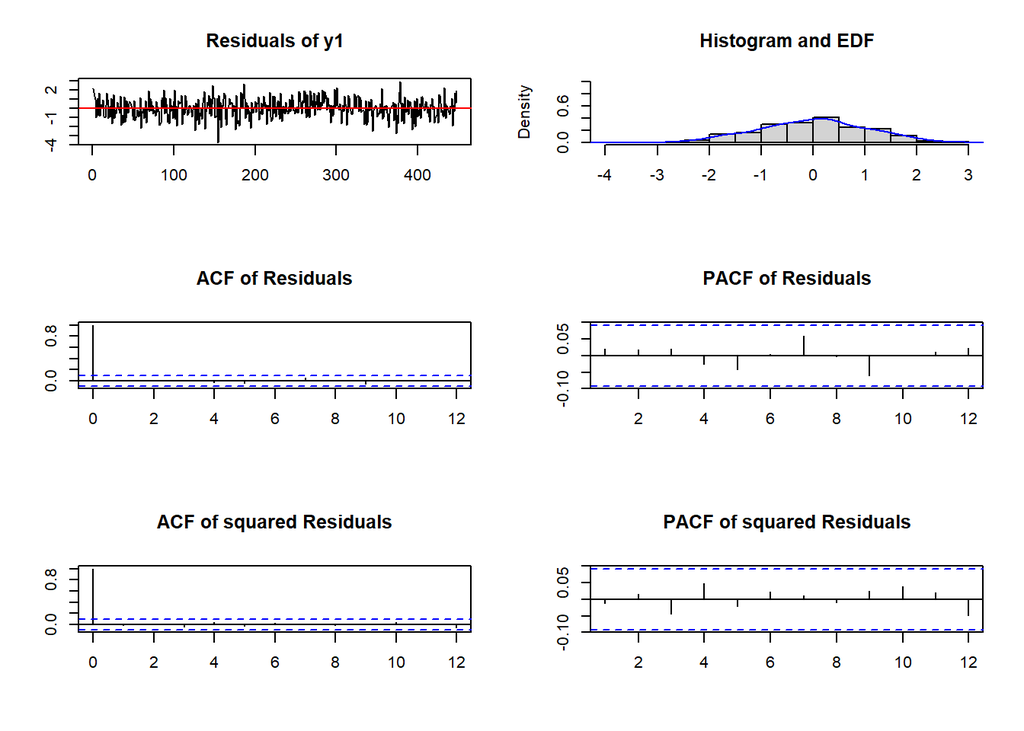

```r
plot(var.test2,names="y1")
```

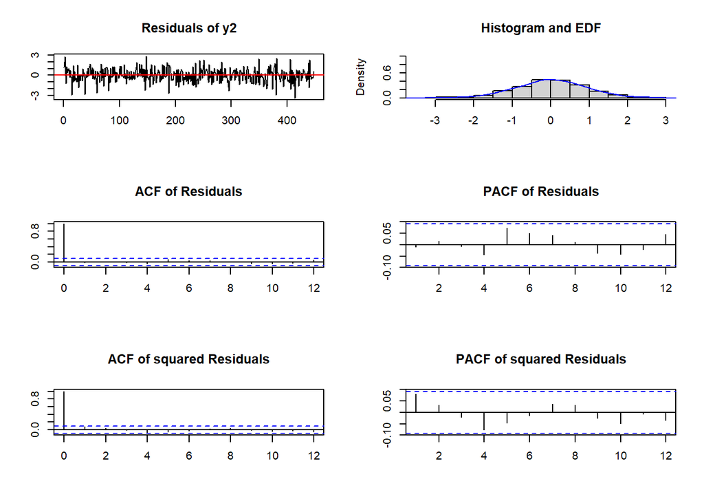

```r
plot(var.test2,names="y2")
```

Puis test de normalité (test de Jarque-Bera).

```r
var.norm2=normality.test(varest2,multivariate.only = TRUE)
var.norm2
```

```
## $JB
##
##  JB-Test (multivariate)
##
## data:  Residuals of VAR object varest2
## Chi-squared = 3.06, df = 4, p-value = 0.5478
##
##
## $Skewness
##
##  Skewness only (multivariate)
##
## data:  Residuals of VAR object varest2
## Chi-squared = 1.4867, df = 2, p-value = 0.4755
##
##
## $Kurtosis
##
##  Kurtosis only (multivariate)
##
## data:  Residuals of VAR object varest2
## Chi-squared = 1.5734, df = 2, p-value = 0.4554
```

### Prédiction

Notre modèle VAR(2) une fois validé, nous pouvons l’utiliser pour la prédiction. Nous fixons un horizon à 10, et traçons les prédictions précédées des 50 dernières valeurs des séries. On observera aussi une petite fantaisie avec la fonction “fanchart”. Parallèlement deux graphique tracent la prédiction et les valeurs test.

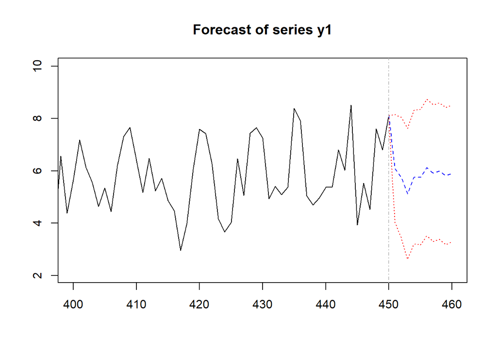

```r
h=10
vardat2.test=vardat2[451:(450+h),]
pred2 = predict(varest2,n.ahead =h ,ci = 0.95)
plot(pred2,names="y1",xlim=c(400,450+h))
```

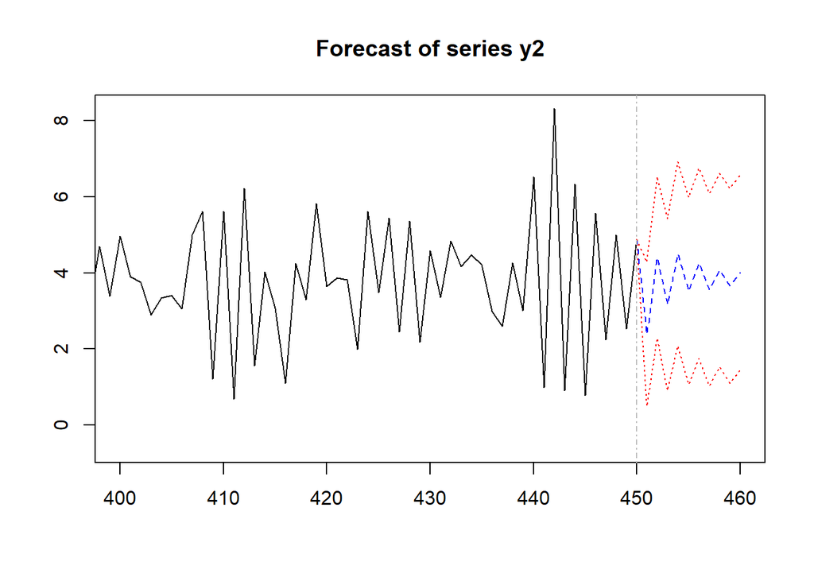

```r
plot(pred2,names="y2",xlim=c(400,450+h))
```

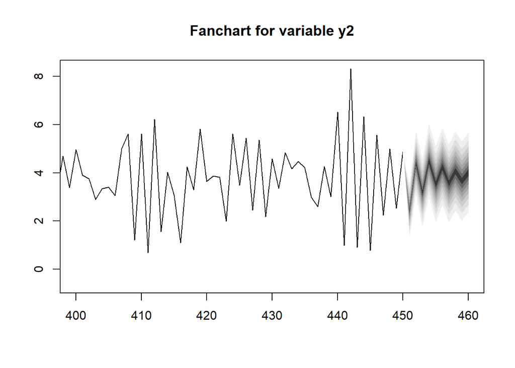

```r
fanchart(pred2,names = "y2",xlim=c(400,450+h))
```

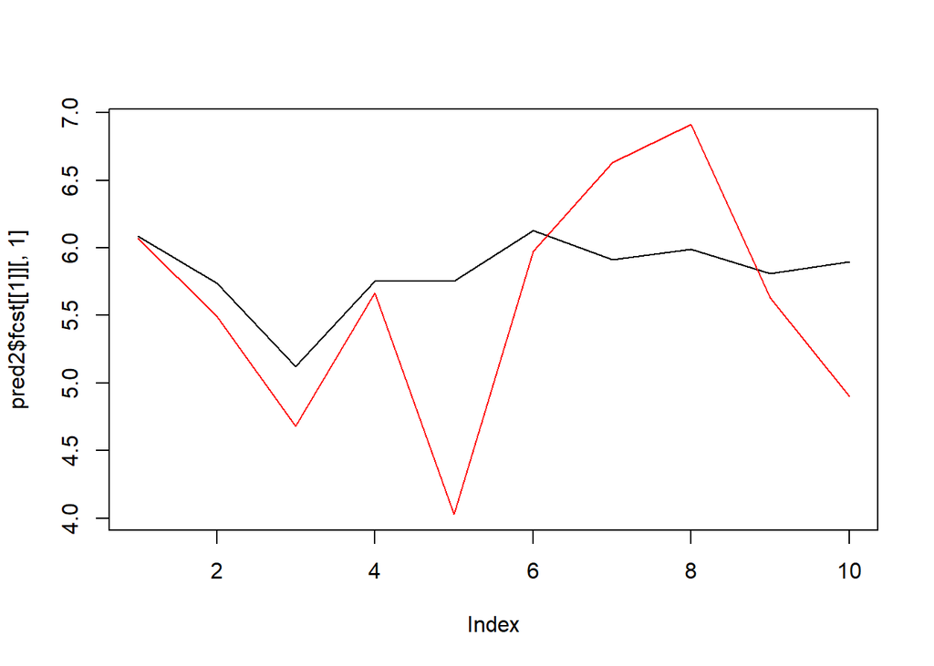

```r
plot(pred2$fcst[[1]][,1],type="l",ylim=c(min(vardat2.test[,1]),max(vardat2.test[,1])))
lines(vardat2.test[,1],col="red")
```

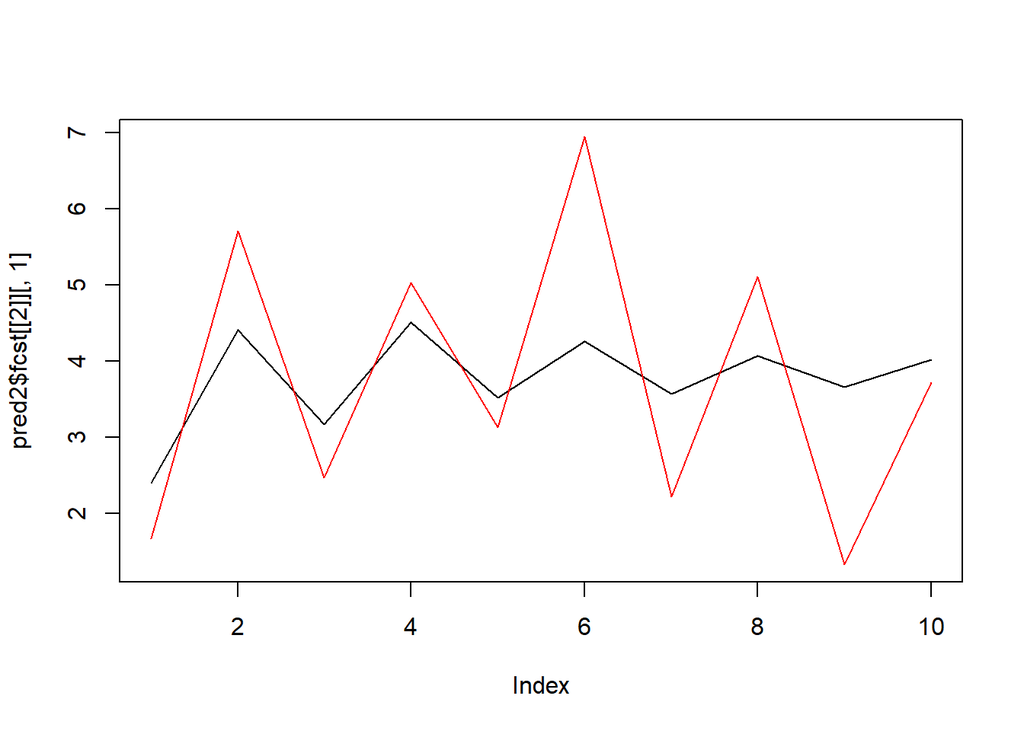

```r
plot(pred2$fcst[[2]][,1],type="l",ylim=c(min(vardat2.test[,2]),max(vardat2.test[,2])))
lines(vardat2.test[,2],col="red")
```

### Causalités

Il nous faut expliquer dans un premier temps ce qu’on entend par causalité au sens de Granger. En voici la définition: Soit deux processus $\left(X_{t}\right)$ et $\left(Y_{t}\right)$, en notant $\underline{X}_{t}=\left\{X_{t}, X_{t-1}, \ldots\right\}$ et $\underline{Y}_{t}=\left\{Y_{t}, Y_{t-1}, \ldots\right\}$ les passés de $\left(X_{t}\right)$ et de $\left(Y_{t}\right)$ ,on dit que $\left(Y_{t}\right)$ cause $\left(X_{t}\right)$ à la date t si et seulement si
$$\mathbb{E}\left(X_{t} | \underline{X}_{t-1}, \underline{Y}_{t-1}\right) \neq \mathbb{E}\left(X_{t} | \underline{X}_{t-1}\right)$$

Autrement dit, Y cause X si la connaissance du passé de Y modifie le comportement de $\left(X_{t}\right)$ Il s’agit d’une causalité de long terme.

Le test de causalité va correspondre à un test de Wald sur les coefficients estimés. Pour déterminer si y2 cause y1 on teste la nullité des coefficients de y2 dans l’expression de y1.

Parallèlement on utilise la causalité instantanée.

$\left(Y_{t}\right)$ cause instantanément $\left(X_{t}\right)$ à la date t si et seulement si
$$\mathbb{E}\left(X_{t} | \underline{X}_{t-1}, \underline{Y}_{t-1}\right) \neq \mathbb{E}\left(X_{t} | \underline{X}_{t-1}, \underline{Y}_{t}\right)$$

l’introduction de Y à l’instant t (présent) dans le membre de droite de l’inégalité modifie le comportement de X (connaissant les passés de X et Y)

```r
causal2=causality( varest2, cause = "y2")
causal2
```

```
## $Granger
##
##  Granger causality H0: y2 do not Granger-cause y1
##
## data:  VAR object varest2
## F-Test = 69.29, df1 = 2, df2 = 886, p-value < 2.2e-16
##
##
## $Instant
##
##  H0: No instantaneous causality between: y2 and y1
##
## data:  VAR object varest2
## Chi-squared = 50.469, df = 1, p-value = 1.211e-12
```

```r
causal1=causality( varest2, cause = "y1")
causal1
```

```
## $Granger
##
##  Granger causality H0: y1 do not Granger-cause y2
##
## data:  VAR object varest2
## F-Test = 39.047, df1 = 2, df2 = 886, p-value < 2.2e-16
##
##
## $Instant
##
##  H0: No instantaneous causality between: y1 and y2
##
## data:  VAR object varest2
## Chi-squared = 50.469, df = 1, p-value = 1.211e-12
```

Nous rejetons les deux hypothèses de non causalité, et concluons à une double causalité (Granger et instantannée).  
Cette dernière est due au fait que nous avons simulé un VAR(2) avec des bruits blancs corrélés.

### Fonction de réponse impulsionnelle

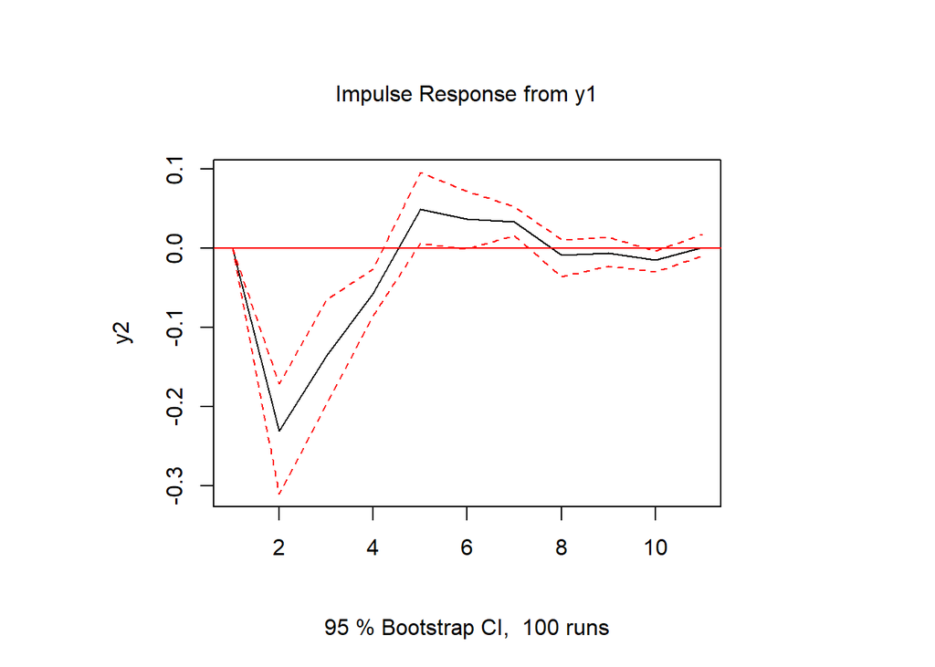

```r
imp_inst.y1=irf(varest2,impulse ="y1",response="y2",n.ahead=10,ortho=FALSE,cumulative=F,boot=T,seed=12345)
plot(imp_inst.y1)
```

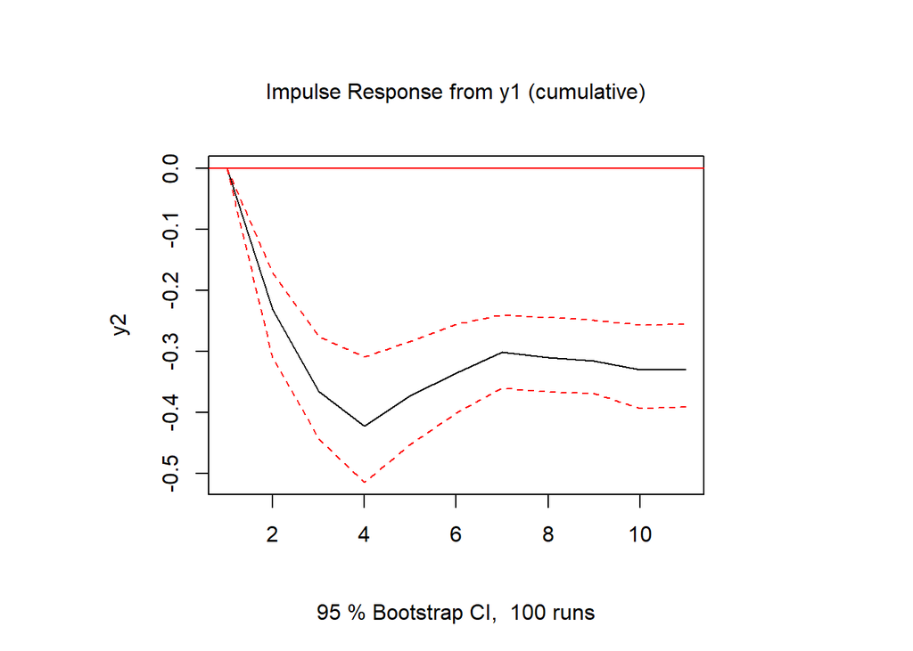

```r
imp_cum.y1=irf(varest2,impulse ="y1",response="y2",n.ahead=10,ortho=FALSE,cumulative=T,boot=T,seed=12345)
plot(imp_cum.y1)
```

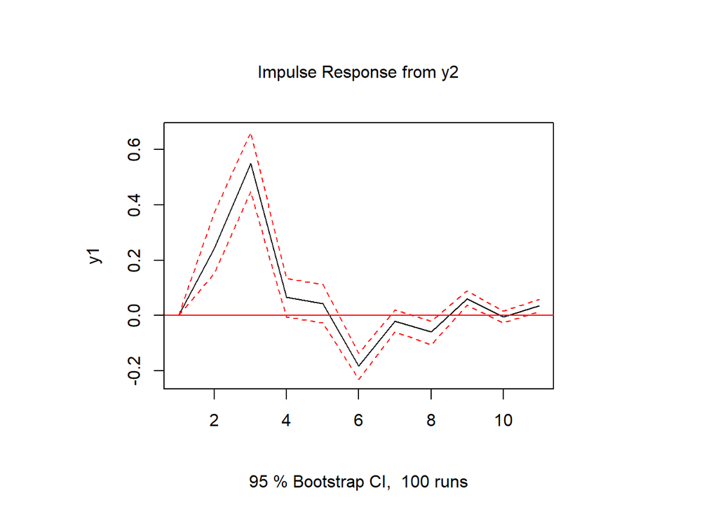

```r
imp_inst.y2=irf(varest2,impulse ="y2",response="y1",n.ahead=10,ortho=FALSE,cumulative=F,boot=T,seed=12345)
plot(imp_inst.y2)
```

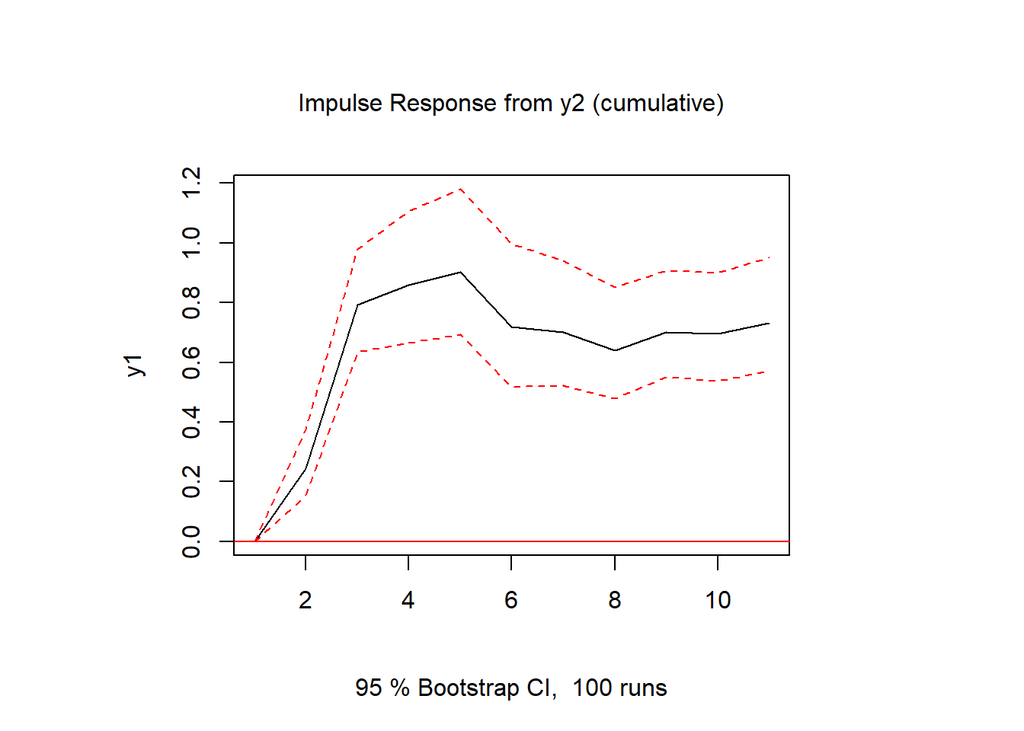

```r
imp_cum.y2=irf(varest2,impulse ="y2",response="y1",n.ahead=10,ortho=FALSE,cumulative=T,boot=T,seed=12345)
plot(imp_cum.y2)
```

L’exemple montre un effet de diminition su Y2 et inverse sur y1.

## Cointégration

Quelques définitions d’abord.

### Série intégrée d’ordre d:

Une série chronologique est dite *intégrée d’ordre d* si d est le plus petit entier tel que $\Delta^{d} X_{t}$ est stationnaire.

Les quatre séries de notre exemple son intégrées d’ordre 1 (on écrit I(1) )

### Séries cointégrées d’ordre d:

Définition: Une famille de séries intégrées intégrées d’ordre d sont dites cointégrées d’ordre C(d,0) ssi il existe une combinaison linéaire de ces séries qui soit stationnaire.

Le test de Johansen permet de déterminer l’éventuelle cointégration.

Avant de procéder au test montrons le rôle que joue cette cointégration dans le modèle VAR.

On se place dans le cas de N variables intégrées I(1), et pour faciliter la compréhension de notre démonstration, nous n’envisageons qu’un VAR(2), mais la généralisation à l’ordre p ne fait aucune difficulté.  
Puisque nos variables sont I(1), leurs différentielles sont stationnaires, et donc bonnes candidates pour un VAR.  
Partons de l’expression VAR.

$$X_{t}=A_{0}+A_{1} X_{t-1}+A_{2} X_{t-2}+\varepsilon_{t}$$
D’où, en retranchant $X_{t-1}$ aux deux membres de l’égalité.
$$X_{t}-X_{t-1}=A_{0}+\left(A_{1}-I\right) X_{t-1}+A_{2} X_{t-2}+\varepsilon_{t}$$
$$\Longleftrightarrow \Delta X_{t}=A_{0}+\left(A_{1}-I\right)\left(X_{t-1}-X_{t-2}\right)+\left(A_{2}+A_{1}-I\right) X_{t-2}+\varepsilon_{t}$$

$$\Longleftrightarrow \Delta X_{t}=A_{0}+\left(A_{1}-I\right) \Delta X_{t-1}+\left(A_{2}+A_{1}-I\right) X_{t-2}+\varepsilon_{t}$$
Là on retranche et rajoute
$$\left(A_{2}+A_{1}-I\right) X_{t-1}$$
pour faire entrer $X_{t-2}$ dans une différence.
$$\begin{aligned}
\Delta X_{t}=& A_{0}+\left(A_{1}-I\right) \Delta X_{t-1}+\left(A_{2}+A_{1}-I\right) X_{t-2}
-\left(A_{2}+A_{1}-I\right) X_{t-1}+\left(A_{2}+A_{1}-I\right) X_{t-1}+\varepsilon_{t}
\end{aligned}$$
On obtient un Var(1) sur les variables différenciées + un terme en $X_{t-1}$.
$$\Delta X_{t}=A_{0}-A_{2} \Delta X_{t-1}+\left(A_{1}+A_{2}-I\right) X_{t-1}+\varepsilon_{t}$$
Ou en renommant les matrices
$$\Delta X_{t}=B_{0}+B_{1} \Delta X_{t-1}+\Pi X_{t-1}+\varepsilon_{t}$$
A ce stade plusieurs cas vont se présenter suivant le rang de la matrice $\Pi$

- $rang(\Pi)=0$ La matrice $\Pi$ est nulle, donc le VAR sur les séries différenciées se déroule normalement.
- $rang(\Pi)=N$ La matrice $\Pi$ est inversible, donc

$$X_{t-1}=\Pi^{-1}\left(\Delta X_{t}-B_{0}-B_{1} \Delta X_{t-1}-\epsilon_{t}\right)$$
$X_{t-1}$ serait égal à une transformation linéaire de variables stationnaires, donc serait elle même stationnaire, ce qui n’est pas vrai dans notre contexte, donc ce cas ne seprésente jamais.

- $rang(\Pi)=1$

Dans ce cas $\Pi X_{t-1}$ est un vecteur de N coordonnées $\lambda_{t-1}u$ u vecteur constant de N coordonnées
$$(\sum_{i}l_{i}X_{i_{t-1}},\beta_{1}\sum_{i}l_{i}X_{i_{t-1}}....)$$
. En posant $\sum_{i}l_{i}X_{i_{t-1}}=\lambda_{t-1}$ et $u=(1,\beta_{2},...\beta_{j...})$ On a alors
$$\Pi X_{t-1}=\lambda_{t-1}u$$

$\lambda_{t-1}$ est un processus univarié stationnaire (la stationnarité de $\lambda_{t-1}$ résulte de l’écriture du VAR sous la forme
$$\Delta X_{t}=B_{0}+B_{1} \Delta X_{t-1}+\lambda_{t-1}u+\varepsilon_{t}$$
De plus l’écriture $\sum_{i}l_{i}X_{i_{t-1}}=\lambda_{t-1}$ indique que les $ X_{i_{t}}$ sont cointégrés d’ordre 1 . En plus on peut réécrire $\Pi X_{t-1}$ sous la forme $u^{'}AX_{t-1}$ où A est la matrice-colonne $L_{1}$ des coefficients de la relation de cointégration. u est appelé force de rappel vers l’équilibre de long terme.

Granger montre (Engle,R.E. & Granger,C.W.J. (1987). ’Cointegration and error-correction : representation, estimation and testing’. Econometrica. 55 ) que dans ce cas il existe deux matrices de rang r $U$ et $V$ telles que $\Pi=U.V^{'}$ telles que $V^{'}X_{t}$ est stationnaire, chaque colonne de V étant un vecteur de cointégration. (il y a donc r relations de cointégration).

###Exemple

Nous créons un Var(1) non stationnaire, et volontairement nous le soumettons au modèle Var. Nous laissons dans notre document le petit chunk suivant qui permettra au lecteur de varier les choix des valeurs propres et ainsi d’exécuter le chunk suivant dans plusieurs configurations.

```r
D=matrix(c(1,0,0,0.3),2,2)      # choix des valeurs propres
P=matrix(c(5,2,2,1),2,2)        # choix du changement de base (matrice de passage)
Q=solve(P)
A=P%*%D%*%Q                     # formule du changement de base
A
```

```
##      [,1] [,2]
## [1,]  3.8 -7.0
## [2,]  1.4 -2.5
```

```r
eigen(A)
```

```
## eigen() decomposition
## $values
## [1] 1.0 0.3
##
## $vectors
##           [,1]      [,2]
## [1,] 0.9284767 0.8944272
## [2,] 0.3713907 0.4472136
```

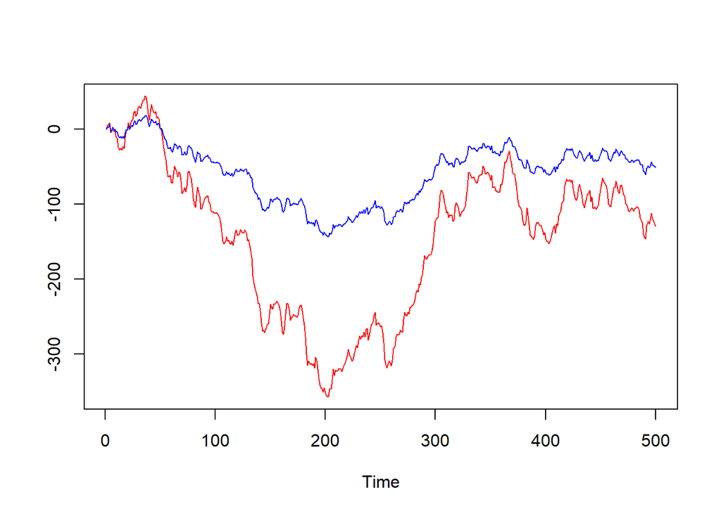

```r
set.seed(123456)
vdat9=var(500,B=A,mod="none")
colnames(vdat9)=c("y1","y2")
ts.plot((vdat9),col=c("red","blue"))
```

```r
#vdat91=t(Q%*%t(vdat9))
#ts.plot(vdat91,col=c("red","blue"))
```

```r
vdat9.train=vdat9[1:450,]

lag=lags.select(vdat9.train,lag.max =4,include="none")
print(lag)
```

```
## Best AIC:  lag= 1
## Best BIC:  lag= 1
## Best HQ :  lag= 1
```

```r
varest9= VAR(vdat9.train,p = 1,type ="none",season = NULL,exogen = NULL)
print(varest9)
```

```
##
## VAR Estimation Results:
## =======================
##
## Estimated coefficients for equation y1:
## =======================================
## Call:
## y1 = y1.l1 + y2.l1
##
##     y1.l1     y2.l1
##  3.789706 -6.975140
##
##
## Estimated coefficients for equation y2:
## =======================================
## Call:
## y2 = y1.l1 + y2.l1
##
##     y1.l1     y2.l1
##  1.386089 -2.465253
```